# Advanced Bioinformatics - Part III

Project 01 - DNA Microarray data analysis in R

## A. Before you begin

### A1. Download R and RStudio

⏰ timing: 1 hour

✅ 1. R is a free software environment for statistical computing and graphics. It runs on UNIX, Windows and MacOS.

- To download and install R go to https://www.r-project.org/ (R Core Team, 2013). The current pipeline was performed using R version 4.2.2.

✅ 2. RStudio is an integrated development environment (IDE) for R. It allows to easily execute the R codes, plot graphics, and manage the workspace in a multipanel interphase.

- To download and install RStudio go to https://rstudio.com/products/rstudio/ (RStudio Team, 2020).

### A2. Download required packages

⏰ timing: 1 hour

✅ 3. Users must first download the required packages (listed in the key resources table). They can be downloaded through Bioconductor, which provides tools for the analysis and comprehension of high-throughput genomic data. BiocManager::install() is the recommended command to install packages (for detailed information on why BiocManager::install() is preferred to the standard R packages installation please read https://www.bioconductor.org/install/#whybiocmanagerinstall):

```r
# construct a new file dir.
print(getwd())
```

```
## [1] "F:/winServer_G/ABI/ABI-Project-01"
```

```r
if (!dir.exists("data")) dir.create("data")
```

- Install the packages needed for the analysis.

```r
if (!requireNamespace("BiocManager", quietly = TRUE))
install.packages("BiocManager")

pkgs <- c("GEOquery", "affy", "simpleaffy", "arrayQualityMetrics")

for (p in pkgs) {
  if (!requireNamespace(p, quietly = TRUE))
BiocManager::install(p)
}
```

- Once all packages are installed, they need to be loaded:

```r
library(GEOquery)
library(affy)
library(simpleaffy)
library(arrayQualityMetrics)
```

### A3. Dataset selection

⏰ timing: 2 days

✅ 4. When using datasets from public repositories, the key step is to identify a dataset (or datasets) that comply with the eligibility criteria and that contains the sample information required for the analysis.

- We suggest browsing Gene Expression Omnibus (GEO: https://www.ncbi.nlm.nih.gov/gds, (Barrett et al., 2012)) and ArrayExpress (https://www.ebi.ac.uk/arrayexpress/, (Athar et al., 2019)) repositories because they gathermultiple high-throughput genomics datasets.
- In this project, publicly available microarray gene expression datasets for asthma were retrieved from the Gene Expression Omnibus Database (GEO) (http://www.ncbi.nlm.nih.gov/geo/) using the keyword “asthma”. The raw datasets were manually checked and only those met the following criteria were included for subsequent analysis: 1) gene expression profiling in asthmatics and controls, 2) cell type: airway epithelial cell, but not nasal epithelium, 3) gene expression data were generated by a single-channel microarray platform (Affymetrix or Agilent chips), 4) availability of raw CEL or TXT files, 5) samples with detailed descriptions, and 6) sample size > 80.
- According to above-mentioned criterion, two datasets were identified, including GSE63142 and GSE67472. Next, We will demonstrate how to conduct data analysis for Affymetrix DNA microarray (*i. e.* GSE67472, https://www.ncbi.nlm.nih.gov/geo/query/acc.cgi?acc=GSE67472).

[figure not shown]

Figure 1. Dataset GSE67472 in GEO database

## B. Materials & Equipment

For this bioinformatics analysis we used a laptop with an Intel Core i5 8th generation processor, 32 GB RAM memory and Windows 10 Pro. No high-performance computing clusters were needed for the analysis of the data. Internet connection is required for downloading R packages and data matrixes.

## C. Step-by-step Methods

### C1. Download and prepare the data matrix for analysis

⏰ timing: 2 hours

You can download the experiment information and clinical data directly from GEO using the GEOquery package:

✅ 5. The series matrix file is a text file that includes a tab-delimited value-matrix for each sample containing the phenotypic/clinical and experimental data of a given dataset. In the GEO webtool, there is a hyperlink to the series matrix, called ‘‘Series Matrix File(s)’’. To download the series matrix file directly to the R environment use the getGEO command:

```r
options(timeout=1000)
#library(GEOquery)
#gse <- getGEO("GSE67472")
#print(gse)
#gsm <- gse[[1]]$geo_accession
#print(gsm)
```

✅ 6. Alternatively, you can download the raw data from GEO database (https://www.ncbi.nlm.nih.gov/geo/query/acc.cgi?acc=GSE67472), as shown in figure 2.

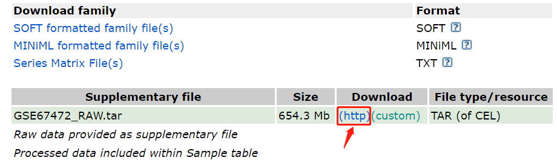

- If you want to download it using the computer program, you may run the following R script:

```r
setwd("./data")
if (file.exists("GSE67472_RAW.tar")) {
  s <- file.info("GSE67472_RAW.tar")
  if (s$size > 600000000) print("Dataset downloading successfully!")
} else {
  # getOption('timeout')
  options(timeout=1000)
  test <- try(getGEOSuppFiles("GSE67472",
                              makeDirectory = TRUE,
                              baseDir = getwd(),
                              fetch_files = TRUE,
                              filter_regex = NULL),
              silent=TRUE)
  if (is.null(class(test))) print("Dataset downloading error!")
}
```

```
## [1] "Dataset downloading successfully!"
```

```r
setwd("..")
```

### C2. Importing data into R environment.

⏰ timing: 10~30 mins

✅ 7. Import the downloaded data into R, according to the following codes.

```r
setwd("./data")
# decompressed file (GSE67472_RAW.tar) to a file dir namely GSE67472.
untar("GSE67472_RAW.tar", exdir = "GSE67472")
print(getwd())
```

```
## [1] "F:/winServer_G/ABI/ABI-Project-01/data"
```

```r
# Import all *.cel files into R environment.
setwd("GSE67472")
library(affy)
dat <- ReadAffy()
setwd("..")
unlink("GSE67472", recursive = TRUE)
print(dat)
```

```
## AffyBatch object
## size of arrays=1164x1164 features (66 kb)
## cdf=HG-U133_Plus_2 (54675 affyids)
## number of samples=105
## number of genes=54675
## annotation=hgu133plus2
## notes=
```

```r
setwd("..")
```

### C3. Quality Assessment for DNA microarray

✅ 8. Optionally, QA is an important step to preprocessing part.

```r
#. if (!dir.exists("QC")) dir.create("QC")
#. setwd("./QC")
#. library(arrayQualityMetrics)
#. err.pos <- arrayQualityMetrics(expressionset = dat,
#.                                outdir = "QA_before",
#.                                force = TRUE)
#. err.cel <- which(err.pos$arrayTable == "x", arr.ind = TRUE)[, 1]
#. print(err.cel)
#. setwd("..")
```

### C4. Microarray data normalization

⏰ timing: 30 mins

✅ 9. There are many algorithm used in DNA microarray data normalization, such as RMA, MAS5.0, GCRMA, PLIER, VSN, and so on. Here, we adopt the RMA.

```r
eset <- rma(dat)
```

```
## Background correcting
## Normalizing
## Calculating Expression
```

```r
print(eset)
```

```
## ExpressionSet (storageMode: lockedEnvironment)
## assayData: 54675 features, 105 samples
##   element names: exprs
## protocolData
##   sampleNames: GSM1647628_08.Fahy_12GOBMUC2_A.CEL.gz
##     GSM1647629_49.Fahy_13GOBMUC2_A.CEL.gz ... GSM1647732_239_new.CEL.gz
##     (105 total)
##   varLabels: ScanDate
##   varMetadata: labelDescription
## phenoData
##   sampleNames: GSM1647628_08.Fahy_12GOBMUC2_A.CEL.gz
##     GSM1647629_49.Fahy_13GOBMUC2_A.CEL.gz ... GSM1647732_239_new.CEL.gz
##     (105 total)
##   varLabels: sample
##   varMetadata: labelDescription
## featureData: none
## experimentData: use 'experimentData(object)'
## Annotation: hgu133plus2
```

```r
eset <- exprs(eset)
cl.name <- sapply(colnames(eset),
                  function(x) strsplit(x, "_")[[1]][1])
colnames(eset) <- cl.name
dim(eset)
```

```
## [1] 54675   105
```

```r
DT::datatable(eset[1:100, 1:4],
              extensions = c('Buttons','FixedColumns','RowGroup'),
              options = list(dom = 'Bfrtip',
                             buttons = c('copy',
                                         'csv',
                                         'excel',
                                         'pdf',
                                         'print')
                             ))
```

|  | GSM1647628 | GSM1647629 | GSM1647630 | GSM1647631 |
| --- | --- | --- | --- | --- |
| 1007_s_at | 10.2868243847168 | 10.4681768711008 | 9.7572811076423 | 10.2718391766984 |
| 1053_at | 5.2544728528017 | 6.0065910403607 | 5.75023285242769 | 5.7653157346236 |
| 117_at | 5.67188034729736 | 6.08414115543725 | 5.92047617034109 | 5.78232831921465 |
| 121_at | 6.40220968684595 | 6.9155597235473 | 6.98611741940574 | 6.41068292560406 |
| 1255_g_at | 4.58105266400945 | 4.41875221040924 | 4.34879458446025 | 4.36032873671316 |
| 1294_at | 7.75886490080473 | 7.69251708075477 | 7.08264726965761 | 7.6593896785676 |
| 1316_at | 5.78250780494339 | 6.31540754322263 | 6.58342348004272 | 6.03927248854301 |
| 1320_at | 5.62625250132351 | 6.04898826583029 | 5.92613944102811 | 5.82264238513176 |
| 1405_i_at | 4.31949349380611 | 4.69248468777825 | 4.11448537881884 | 3.98421366199613 |
| 1431_at | 4.91652567945133 | 5.01002255825433 | 4.79529019925646 | 4.85488314873114 |

[output cut: 90 more lines]

✅ 10. Download [annotation file](https://www.ncbi.nlm.nih.gov/geo/query/acc.cgi?mode=raw&is_datatable=true&acc=GPL570&id=55999&db=GeoDb_blob143) for hgu133plus2.0 platform, and save it as “GPL570-hgu133plus2.txt”.

```r
hgu133plus2 <- read.csv("GPL570-hgu133plus2.txt",
                        sep = "\t",
                        skip = 16,
                        header = TRUE)
dim(hgu133plus2)
```

```
## [1] 54675    16
```

✅ 11. Annotation files were processed to extract information that was available in this study.

```r
### For hgu133plus2, annotation information, GSE67472.
### 1) Find out the probes which match multiple genes, or are unknown.
o2m.p.133p2 <- NULL
len.stat <- NULL
for (i in 1:nrow(hgu133plus2)) {
  a <- as.character(hgu133plus2$ENTREZ_GENE_ID[i])
  tmp <- strsplit(a, " /// ")[[1]]
  len.stat <- c(len.stat, length(tmp))
  if (length(tmp) > 1 | length(tmp) == 0) {
    o2m.p.133p2 <- c(o2m.p.133p2, i)
  }
}
o2m.p <- length(o2m.p.133p2)
word1 <- paste("There are",
               o2m.p,
               "probes which matched more than one genes!")
print(word1)
```

```
## [1] "There are 12841 probes which matched more than one genes!"
```

```r
# sum(table(len.stat)) - 41834
# table(is.na(hgu133plus2$ENTREZ_GENE_ID))
# which(o2m.p.95av2 == "4721")
### If you want, you can remove the o2m probes from annotation file.
anno.133p2 <- hgu133plus2[-o2m.p.133p2, c(1, 11, 12)]
# table(unique(anno.133p2$ID) == anno.133p2$ID)

# 2) Find out the probes which match only one gene.
# i. e., one probe, one gene.
o2o <- table(anno.133p2$ENTREZ_GENE_ID) == 1
o2o.133p2 <-  names(table(anno.133p2$ENTREZ_GENE_ID))[o2o]
length(o2o.133p2)
```

```
## [1] 9792
```

```r
# 3) Find out the genes which match the more probes.
# i., e., more probes, one gene.
m2o <- table(anno.133p2$ENTREZ_GENE_ID) > 1
m2o.133p2 <-  names(table(anno.133p2$ENTREZ_GENE_ID))[m2o]
length(m2o.133p2)
```

```
## [1] 10694
```

✅ 12. Extract (or prepare) the gene expression matrix from GSE67472.

```r
### 1) Extracting one2one gene expression levels.
mat.67472 <- NULL
probe.67472 <- rownames(eset)
for (s in o2o.133p2) {
  s.pos <- which(anno.133p2$ENTREZ_GENE_ID == s)
  if (length(s.pos) > 1) print(s.pos)
  s.tmp <- eset[which(probe.67472 == anno.133p2$ID[s.pos]), ]
  # rownames(mat.tmp) <- s
  mat.67472 <- rbind(mat.67472, s.tmp)
}

### 2) Extracting more2one gene expression levels.
for (m in m2o.133p2) {
  m.pos <- which(anno.133p2$ENTREZ_GENE_ID == m)
  m.tmp <- eset[match(anno.133p2$ID[m.pos], probe.67472), ]
  # if (nrow(m.tmp) > 1) print(m.tmp)
  tmp <- m.tmp[which.max(apply(m.tmp, 1, IQR)), ]
  mat.67472 <- rbind(mat.67472, tmp)
}
rownames(mat.67472) <- c(o2o.133p2, m2o.133p2)

### 3) Previewing the gene expression matirx.
head(mat.67472)
```

```
##           GSM1647628 GSM1647629 GSM1647630 GSM1647631 GSM1647632 GSM1647633
## 1           3.493539   3.815563   3.610844   3.594420   3.515792   3.598956
## 10          4.221160   3.994366   4.081684   4.095276   3.995225   4.061557
## 100048912   4.411851   4.262043   4.288609   4.715922   4.240065   4.113609
## 10007       7.675279   7.129691   7.091532   7.330977   7.301560   8.066077
## 100093698   4.756881   4.745557   5.290200   4.797684   4.655890   4.643768
## 1001        8.085951   7.931672   7.757693   7.567498   7.942103   8.091432
##           GSM1647634 GSM1647635 GSM1647636 GSM1647637 GSM1647638 GSM1647639
## 1           3.524817   3.786830   3.607734   3.624177   3.631540   3.980450
## 10          4.045187   3.731648   4.031600   3.922030   3.959078   3.965483
## 100048912   4.634525   4.083764   4.424771   4.278938   4.286333   4.130990
## 10007       7.237745   7.778026   7.022828   7.480860   8.087107   7.756052
## 100093698   4.625860   4.654817   4.520235   4.581960   4.500682   4.694741
## 1001        8.008257   7.731630   7.966563   8.083884   7.962252   8.129002
##           GSM1647640 GSM1647641 GSM1647642 GSM1647643 GSM1647644 GSM1647645
```

[output cut: 111 more lines]

```r
tail(mat.67472)
```

```
##      GSM1647628 GSM1647629 GSM1647630 GSM1647631 GSM1647632 GSM1647633
## 9987   8.797270   9.543499  10.196649   9.676556   9.926735   8.229028
## 999    5.087675   4.777227   4.619528   4.563001   4.851726   4.342094
## 9990   4.749497   4.817312   4.763305   4.536702   4.934358   4.470848
## 9991   3.489513   3.847950   3.519479   3.465999   3.720478   3.571195
## 9993   5.993702   6.638650   6.401174   6.405897   6.580947   6.278414
## 9994   4.715041   3.873419   4.268575   4.505541   3.731421   4.320570
##      GSM1647634 GSM1647635 GSM1647636 GSM1647637 GSM1647638 GSM1647639
## 9987   9.628917   9.833227   9.693346   8.992126   8.708899   8.838605
## 999    4.814504   4.686905   4.635453   4.611680   4.501259   4.539497
## 9990   4.797551   5.157497   4.736082   4.530546   4.791117   4.714043
## 9991   3.510455   3.749444   3.634873   3.565544   3.502093   3.364446
## 9993   6.336191   6.338804   6.183747   6.486892   6.318802   6.415717
## 9994   4.215959   3.658543   4.321291   4.310333   4.197945   4.094475
##      GSM1647640 GSM1647641 GSM1647642 GSM1647643 GSM1647644 GSM1647645
```

[output cut: 111 more lines]

```r
dim(mat.67472)
```

```
## [1] 20486   105
```

```r
print(getwd())
```

```
## [1] "F:/winServer_G/ABI/ABI-Project-01"
```

### C5. Differential gene expression analysis across different conditions

⏰ timing: 1 day

✅ 13. Before identifying the differentially expressed genes, you must offer the sample information (sample labels, or groups).

- Here, we grabbed the sample information on GSE67472, from ArrayExpress database (https://www.ebi.ac.uk/arrayexpress/).

```r
sample.url <- paste("https://www.ebi.ac.uk/biostudies/files",
                    "E-GEOD-67472/E-GEOD-67472.sdrf.txt",
                    sep = "/")
sample.info <- read.csv(sample.url, sep = "\t", header = TRUE)
sample.info <- sample.info[, c(33, 46, 47, 50, 53)]
names(sample.info) <- c("Assay", "Age", "State", "Sex", "Group")
DT::datatable(sample.info)
```

|  | Assay | Age | State | Sex | Group |
| --- | --- | --- | --- | --- | --- |
| 1 | GSM1647732 | 57 | asthma | female | high |
| 2 | GSM1647731 | 54 | asthma | male | high |
| 3 | GSM1647730 | 23 | asthma | female | low |
| 4 | GSM1647729 | 23 | asthma | male | low |
| 5 | GSM1647728 | 46 | healthy | female | not specified |
| 6 | GSM1647727 | 41 | healthy | male | not specified |
| 7 | GSM1647726 | 22 | asthma | male | low |
| 8 | GSM1647725 | 20 | asthma | male | high |
| 9 | GSM1647724 | 39 | asthma | male | high |
| 10 | GSM1647723 | 26 | asthma | male | low |

[output cut: 95 more lines]

### C6. Correlation analysis

⏰ timing: 1 day

### C7. Patient segregation based on gene expression

⏰ timing: 1 day

## D. About Statistical Analysis

Eligibility criteria, statistical tests and software used for this protocol are properly described in the ‘‘before you begin’’ and ‘‘step-by-step methods details’’ sections.

- Statistics index used in this project includ mean, sd, CV, T statistics, fold change (FC), p value, and so on.

$$\sigma = \sqrt{ \frac{1}{N} \sum_{i=1}^N (x_i -\mu)^2}$$

## E. Reference

📰 Nie X, Wei J, Hao Y, *et al*. Consistent biomarkers and related pathogenesis underlying asthma revealed by systems biology approach[J]. *International journal of molecular sciences*, 2019, 20(16): 4037.